# Pardee Skills Workshop: Data Manipulation and Visualization Basics using R

Mickey Rafa

May 15, 2018

# 1 Overview

This workshop session will help you familiarize with two of R’s most widely used packages, `dplyr` and `ggplot2`. These packages are part of what is called the **tidyverse**, which is a collection of packages that are designed to work together in R to simplify and data manipulation, discovery, visualization, analysis, and more.[^1]

[figure not shown]

Each tile is a package that makes up the “tidyverse”

`dplyr` is designed to standardize the data management and manipulation process in R. `dplyr` has a small set of functions that help users navigate the most common challenges of data manipulation.[^2] Generally speaking, these include restructuring, filtering, grouping, and summarizing your data, as well as creating new variables for your analysis.

`ggplot2` is a package for visualizing data. In this lesson, we will learn the building blocks for creating beautiful visualizations. We will learn how to produce **histograms**, **scatter plots**, and **line plots**, and we will visualize ungrouped and grouped data.

`dplyr` and `ggplot2` are packages that supply a **grammar** for data manipulation and data visualization, respectively. This workshop will only scratch the surface of what is possible, but learning the fundamentals of these packages can empower you to do a ton of exciting things in R.

# 2 Introduction

## 2.1 Workshop format and key terms

Two quick notes on the format of this workshop:

1. There are links to additional resources in the end notes of this document. I have personally used most of these resources to build my skills in R, so I hope you will find them useful, too.
2. Throughout the workshop, there will be exercises to complete on your own or with your table mates. Do you best to complete these based on what you’ve learned. If you get stuck, you can click the “Code” button on the right to show the code that I would use to answer the question. Use that to test yourself and figure out why it works.

There are a few **key terms** that we’ll use throughout this session.

[output not shown]

## 2.2 Setting up your R Project environment

To get started, we need to set up our new **project environment**, with the following steps:

1. Open R Studio, and go to **File** –> **New Project**.

[figure not shown]

2. Select **New Directory**.

[figure not shown]

3. Select **New Project**.

[figure not shown]

4. Type in a name for your project under “Directory name”. Choose the location where you want this R Project to live on your computer. Select **Create Project**.

[figure not shown]

These steps have established a directory on your computer where your R project lives. This is a very good practice to keep when you are starting a new analysis. You will keep all related files in this project folder, and R will know that this is your **working directory** (where all files relevant to your project are saved).

5. Finally, go to **File** –> **New File** –> **R Notebook**. R notebook files are an excellent way to perform an analysis, because they allow for R code and documentation to work side-by-side. This enables you to tell a story that moves alongside your quantitative analysis, and it can be output in all kinds of formats, including Word documents, .pdfs, and .html files.

[figure not shown]

We could do a full session on R projects and notebooks, but this should be sufficient to get you started.

# 3 The Gapminder dataset

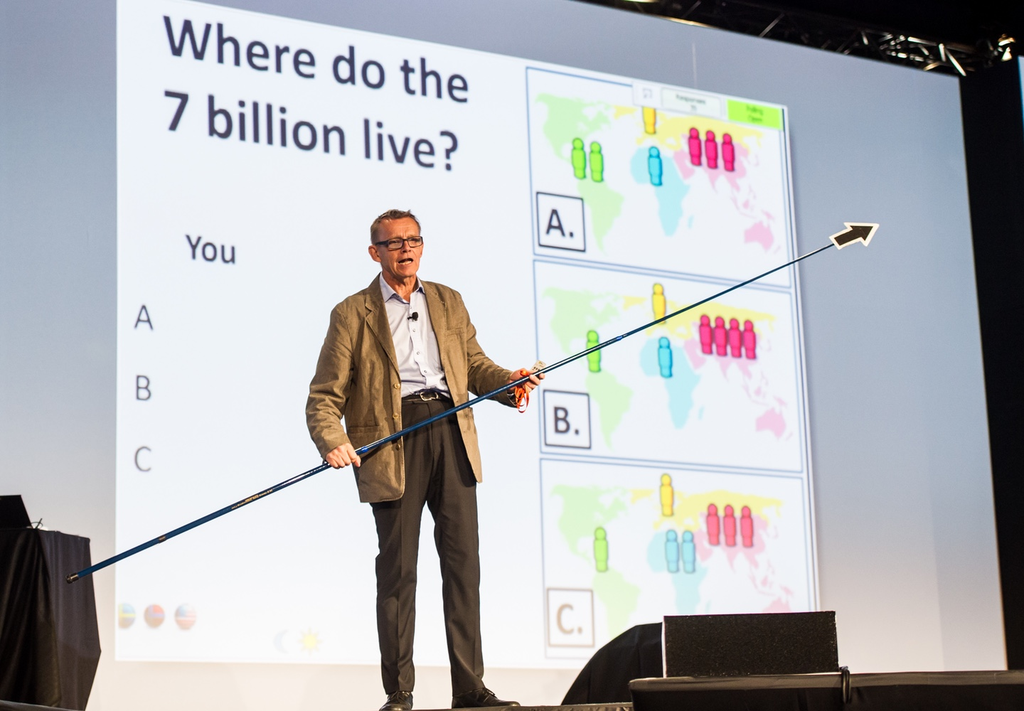

Hans Rosling – our favorite Swedish statistician

We’ll learn the main `dplyr` functions using the **gapminder** dataset. Now that we have our project environment set up, some brief refreshers from the previous workshop:

1. Install the tidyverse and gapminder packages (`install.packages()`)

```r
install.packages("tidyverse")
```

2. Load the tidyverse and gapminder packages (`library()` and `require()` effectively do the same thing, but `library()` provides more information that is occasionally useful)

```r
library(tidyverse)      #for data management, manipulation, visualization, and exploratory data analysis
library(gapminder)      #for the gapminder dataset
```

3. Type in `data("gapminder")` to read in the gapminder dataset as an object in your global environment.

```r
data("gapminder")
```

4. Look at the structure of the gapminder dataset (`str()` and `glimpse()` both work here)

```r
str(gapminder)
```

```
Classes ‘tbl_df’, ‘tbl’ and 'data.frame':   1704 obs. of  6 variables:
 $ country  : Factor w/ 142 levels "Afghanistan",..: 1 1 1 1 1 1 1 1 1 1 ...
 $ continent: Factor w/ 5 levels "Africa","Americas",..: 3 3 3 3 3 3 3 3 3 3 ...
 $ year     : int  1952 1957 1962 1967 1972 1977 1982 1987 1992 1997 ...
 $ lifeExp  : num  28.8 30.3 32 34 36.1 ...
 $ pop      : int  8425333 9240934 10267083 11537966 13079460 14880372 12881816 13867957 16317921 22227415 ...
 $ gdpPercap: num  779 821 853 836 740 ...
```

Looking at the general structure of the dataset gives us a few useful insights:

- Object class
- Rows and columns
- Variable types: factor (categorical) vs. numeric/integer

Use the `summary()` command to produce a high-level statistical summary of the variables.

```r
summary(gapminder)
```

```
        country        continent        year         lifeExp           pop              gdpPercap
 Afghanistan:  12   Africa  :624   Min.   :1952   Min.   :23.60   Min.   :6.001e+04   Min.   :   241.2
 Albania    :  12   Americas:300   1st Qu.:1966   1st Qu.:48.20   1st Qu.:2.794e+06   1st Qu.:  1202.1
 Algeria    :  12   Asia    :396   Median :1980   Median :60.71   Median :7.024e+06   Median :  3531.8
 Angola     :  12   Europe  :360   Mean   :1980   Mean   :59.47   Mean   :2.960e+07   Mean   :  7215.3
 Argentina  :  12   Oceania : 24   3rd Qu.:1993   3rd Qu.:70.85   3rd Qu.:1.959e+07   3rd Qu.:  9325.5
 Australia  :  12                  Max.   :2007   Max.   :82.60   Max.   :1.319e+09   Max.   :113523.1
 (Other)    :1632
```

> Before we start into the gapminder analysis, note that this is a **“cleaned”** dataset. There are no missing values, major issues with data types, or values that could be flagged as suspicious. That was a conscious choice for this workshop, so that we could get into data manipulation and visualization. In your own work, it is extremely likely that you will need to do more data preparation before analysis.

# 4 dplyr’s main functions

## 4.1 distinct()

To begin our anlaysis, let’s look at the years that are available in the gapminder dataset. There are many ways to do this, but I’ll use the `distinct()` function from `dplyr`.

**Create a new code chunk (Ctrl + Alt + I), and type `gapminder %>% distinct(year)`.** Then, execute the code chunk (with the green play button in the upper righthand corner of the chunk).

```r
gapminder %>%
  distinct(year)
```

| year |
| --- |
| 1952 |
| 1957 |
| 1962 |
| 1967 |
| 1972 |
| 1977 |
| 1982 |
| 1987 |
| 1992 |
| 1997 |

[output cut: 2 more lines]

This shows us that we have data that are in five-year increments from 1952 to 2007.

Before we move on, let’s take a closer look at the code above, because it uses a style that we will be fluent in by the end of this session. This code uses “**piping**” (the %>%), which is a coding style that makes code more readable and easier to troubleshoot.[^3] The “pipe” (%>%) tells R to take the object to the left of the pipe and feed it to the first argument in the code following the pipe. The code above can be read as:

- Take the `gapminder` dataframe and feed it into the `distinct()` function, THEN
- Return the distinct or unique values in the `year` column

When reading your code, you can think of the **pipe operator (%>%)** as “THEN”. To use the above example, take the gapminder dataframe, **THEN** return the distinct values in the year column.

Let’s look at the **distinct continents** in the gapminder dataset. In your code chunk, relace `distinct(year)` with `distinct(continent)`. Then, with your cursor on the same line as the code, **use the keyboard shortcut for running a block of code (Ctrl + Enter)**.

```r
gapminder %>%
  distinct(continent)
```

| continent |
| --- |
| Asia |
| Europe |
| Africa |
| Americas |
| Oceania |

This is how the code looks without piping. Not too difficult (yet).

> distinct(gapminder, continent)

This simple example does not convey the full value of piping, but that will be clear by the end of the session.

## 4.2 filter()

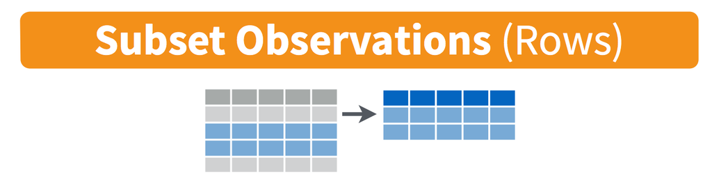

The `filter()` function allows you to subset your data by values of the variables in your dataset.

**We’re going to use piping a lot in this session**, so let’s get comfortable with it. Try using the pipe operator keyboard shortcut (**Ctrl + Shift + M**) with your code from this point forward.

Let’s filter the gapminder dataframe to look at only the values in the year 2007.

```r
gapminder %>%
  filter(year == 2007)
```

| country | continent | year | lifeExp | pop | gdpPercap |
| --- | --- | --- | --- | --- | --- |
| Afghanistan | Asia | 2007 | 43.828 | 31889923 | 974.5803 |
| Albania | Europe | 2007 | 76.423 | 3600523 | 5937.0295 |
| Algeria | Africa | 2007 | 72.301 | 33333216 | 6223.3675 |
| Angola | Africa | 2007 | 42.731 | 12420476 | 4797.2313 |
| Argentina | Americas | 2007 | 75.320 | 40301927 | 12779.3796 |
| Australia | Oceania | 2007 | 81.235 | 20434176 | 34435.3674 |
| Austria | Europe | 2007 | 79.829 | 8199783 | 36126.4927 |
| Bahrain | Asia | 2007 | 75.635 | 708573 | 29796.0483 |
| Bangladesh | Asia | 2007 | 64.062 | 150448339 | 1391.2538 |
| Belgium | Europe | 2007 | 79.441 | 10392226 | 33692.6051 |

[output cut: 132 more lines]

This returns the 142 records (or rows) that are in the year 2007.

What’s the double equal sign (“**==**”) mean? This is a **boolean equal**, meaning that it is evaluating whether the equation returns a TRUE or FALSE. The above code can be read as “filter, return rows in which the variable year equals 2007”. All rows that would return a TRUE for “year equals 2007” are displayed.

You can also use the `filter()` command on multiple conditions, too. Just separate the conditions with a comma. The code below takes the gapminder dataframe, and filters the data in which the **country** is South Africa and the **year** is 2007.

```r
gapminder %>%
  filter(country == 'South Africa',
         year == 2007)
```

| country | continent | year | lifeExp | pop | gdpPercap |
| --- | --- | --- | --- | --- | --- |
| South Africa | Africa | 2007 | 49.339 | 43997828 | 9269.658 |

This shows that the dataset has only one occurrence of South Africa in 2007. Note that in `dplyr`, separating arguments with a comma allows you to combine multiple logical expressions. How would you read the above code aloud?

**One thing to keep in mind** – your data object remains unchanged, unless you assign the `filter()` to a new object. To save the above code as a new object, you need to assign it to a new named object, such as:

> sa_2007 <- gapminder %>% filter(country == ‘South Africa’, year == 2007)

## 4.3 arrange()

The `arrange()` function sorts your data – a very common thing to do in an exploratory data analysis. Let’s arrange the gapminder data by life expectancy (the variable is called **lifeExp**).

```r
gapminder %>%
  arrange(lifeExp)
```

| country | continent | year | lifeExp | pop | gdpPercap |
| --- | --- | --- | --- | --- | --- |
| Rwanda | Africa | 1992 | 23.59900 | 7290203 | 737.0686 |
| Afghanistan | Asia | 1952 | 28.80100 | 8425333 | 779.4453 |
| Gambia | Africa | 1952 | 30.00000 | 284320 | 485.2307 |
| Angola | Africa | 1952 | 30.01500 | 4232095 | 3520.6103 |
| Sierra Leone | Africa | 1952 | 30.33100 | 2143249 | 879.7877 |
| Afghanistan | Asia | 1957 | 30.33200 | 9240934 | 820.8530 |
| Cambodia | Asia | 1977 | 31.22000 | 6978607 | 524.9722 |
| Mozambique | Africa | 1952 | 31.28600 | 6446316 | 468.5260 |
| Sierra Leone | Africa | 1957 | 31.57000 | 2295678 | 1004.4844 |
| Burkina Faso | Africa | 1952 | 31.97500 | 4469979 | 543.2552 |

[output cut: 990 more lines]

This shows us that Rwanda in 1992 is the lowest life expectancy in the dataset. By default, the `arrange()` function sorts your data in ascending order. What if we want to sort the data by the largest GDP per capita (variable is **gdpPercap**) in the dataset?

```r
gapminder %>%
  arrange(-gdpPercap)
```

| country | continent | year | lifeExp | pop | gdpPercap |
| --- | --- | --- | --- | --- | --- |
| Kuwait | Asia | 1957 | 58.033 | 212846 | 113523.133 |
| Kuwait | Asia | 1972 | 67.712 | 841934 | 109347.867 |
| Kuwait | Asia | 1952 | 55.565 | 160000 | 108382.353 |
| Kuwait | Asia | 1962 | 60.470 | 358266 | 95458.112 |
| Kuwait | Asia | 1967 | 64.624 | 575003 | 80894.883 |
| Kuwait | Asia | 1977 | 69.343 | 1140357 | 59265.477 |
| Norway | Europe | 2007 | 80.196 | 4627926 | 49357.190 |
| Kuwait | Asia | 2007 | 77.588 | 2505559 | 47306.990 |
| Singapore | Asia | 2007 | 79.972 | 4553009 | 47143.180 |
| Norway | Europe | 2002 | 79.050 | 4535591 | 44683.975 |

[output cut: 990 more lines]

```r
#you could also do...
#gapminder %>%
#  arrange(desc(gdpPercap))
#or if you wanted to return the top X GDP per capita records
#you could use the top_n() function from dplyr
#gapminder %>%
#  arrange(-gdpPercap) %>%
#  top_n(15, gdpPercap)
```

**Exercises**:

- You can also arrange by multiple variables with the `arrange()` function. Let’s say that you want to arrange the gapminder data by year and by life expectancy. Try using `gapminder %>% arrange(year, lifeExp)`. What do you see?

```r
gapminder %>%
  arrange(year, lifeExp)
```

- Let’s put the `filter()` and `arrange()` functions together. I’d like to see the **life expectancy of all Asian countries from the year 2000 to the most recent year, sorted in ascending order**. How might we do that?

```r
gapminder %>%
  filter(year >= 2000,
         continent == 'Asia') %>%
  arrange(lifeExp)
```

When you are combining multiple functions, the power and clarity of piping becomes more obvious. This is what the previous code would look like **without piping**.

> arrange(filter(gapminder, year >= 2000, continent == ‘Asia’), lifeExp)

**Who would like to try to read this?**

Without piping, you need to write this code inside-out! Does anyone actually find this easier?!

## 4.4 mutate()

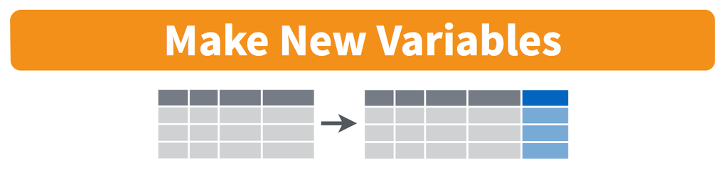

In data analysis, it’s common to want to create or *derive* new variables from your original dataset. This is done with the `dplyr::mutate()` function. For example, you might want to create a variable that is the distance in time from the beginning of the dataset. This is a typical derived variable used in regression modeling.

For these new variables, let’s save this as a new data object.

```r
gapminder <- gapminder %>%
  mutate(time_dist = year - 1952)
print(gapminder)
```

| country | continent | year | lifeExp | pop | gdpPercap | time_dist |
| --- | --- | --- | --- | --- | --- | --- |
| Afghanistan | Asia | 1952 | 28.80100 | 8425333 | 779.4453 | 0 |
| Afghanistan | Asia | 1957 | 30.33200 | 9240934 | 820.8530 | 5 |
| Afghanistan | Asia | 1962 | 31.99700 | 10267083 | 853.1007 | 10 |
| Afghanistan | Asia | 1967 | 34.02000 | 11537966 | 836.1971 | 15 |
| Afghanistan | Asia | 1972 | 36.08800 | 13079460 | 739.9811 | 20 |
| Afghanistan | Asia | 1977 | 38.43800 | 14880372 | 786.1134 | 25 |
| Afghanistan | Asia | 1982 | 39.85400 | 12881816 | 978.0114 | 30 |
| Afghanistan | Asia | 1987 | 40.82200 | 13867957 | 852.3959 | 35 |
| Afghanistan | Asia | 1992 | 41.67400 | 16317921 | 649.3414 | 40 |
| Afghanistan | Asia | 1997 | 41.76300 | 22227415 | 635.3414 | 45 |

[output cut: 990 more lines]

**Exercises**:

- Use `dplyr::mutate()` to create two other variables – **GDP** and **population (in millions)**. Note that just like the `filter()` function, which allows you to have multiple conditions, you can also create multiple new variables by using a comma within `mutate()`.

```r
gapminder <- gapminder %>%
  mutate(gdp = gdpPercap * pop,
         pop = pop/1000000)
```

- What are the countries with the largest total GDP in 2007?

```r
gapminder %>%
  filter(year == 2007) %>%
  arrange(desc(gdp))
```

## 4.5 summarise()

In your own anlayses, you’ve probably calculated summary stats for variables. Earlier, we used `summary(gapminder)` to get an overview of the gapminder dataset, based on some preset functions. `summarise()` can produce the same summary statistics as `summary()`, but you have total control over the output (it can do some neat things with grouped data, too, which you will see later). Think of `summarise()` as useful when you want to condense many rows of data down into a smaller number of rows with summary information.

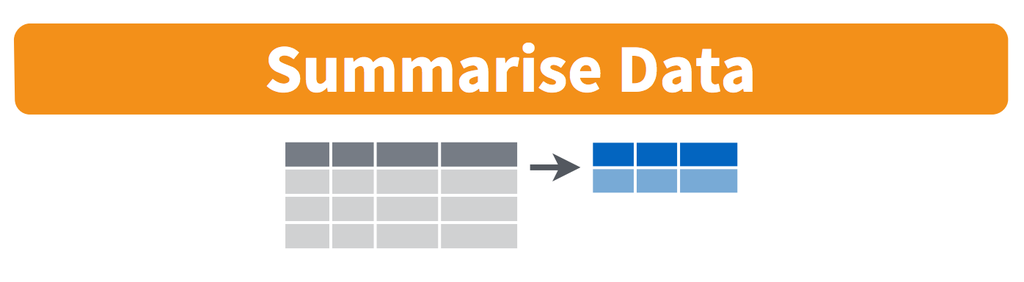

The `summarise()` function follows the same syntax as `mutate()`, which is used for creating or deriving new variables, too. The difference is that `summarise()` is creating a new **grouped** variable with an **aggregate function**. Using the gapminder dataset as an example, what is the mean life expectancy from the dataset?

```r
gapminder %>%
  summarise(meanlifeExp = mean(lifeExp))
```

| meanlifeExp |
| --- |
| 59.47444 |

This code is returning the average life expectancy for all countries and years in the dataset.

**Exercise**:

- What happens if you use `mutate()` instead of `summarise()` to calculate the average life expectancy for the data? Why is that different from using `summarise()`?

```r
gapminder %>%
  mutate(meanlifeExp = mean(lifeExp))
```

This may be useful for your research question, but it is far more likely that you’ll want to summarise a variable like **lifeExp** by a **grouping variable**. For instance, what is the average life expectancy from this dataset **by year**? Anytime you want to summarise a variable “BY” another variable, `dplyr::group_by()` comes in handy.

```r
gapminder %>%
  group_by(year) %>%
  summarise(meanlifeExp = mean(lifeExp))
```

| year | meanlifeExp |
| --- | --- |
| 1952 | 49.05762 |
| 1957 | 51.50740 |
| 1962 | 53.60925 |
| 1967 | 55.67829 |
| 1972 | 57.64739 |
| 1977 | 59.57016 |
| 1982 | 61.53320 |
| 1987 | 63.21261 |
| 1992 | 64.16034 |
| 1997 | 65.01468 |

[output cut: 2 more lines]

The above code groups the gapminder dataset by the **year** variable and computes the average life expectancy per year. This shows the gradual advancement in global average life expectancy over time. Pretty neat!

The gapminder dataset begs the question: how has the average life expectancy changed over time and across continents? Said another way, how has average life expectancy changed **BY** year and **BY** continent? **BY** is a hint that you want to group your data to answer your question. Just like previous functions that we’ve learned (such as `filter()` and `mutate()`), you can group your data by multiple conditions with comma.

```r
gapminder %>%
  group_by(year, continent) %>%
  summarise(meanlifeExp = mean(lifeExp))
```

| year | continent | meanlifeExp |
| --- | --- | --- |
| 1952 | Africa | 39.13550 |
| 1952 | Americas | 53.27984 |
| 1952 | Asia | 46.31439 |
| 1952 | Europe | 64.40850 |
| 1952 | Oceania | 69.25500 |
| 1957 | Africa | 41.26635 |
| 1957 | Americas | 55.96028 |
| 1957 | Asia | 49.31854 |
| 1957 | Europe | 66.70307 |
| 1957 | Oceania | 70.29500 |

[output cut: 50 more lines]

With this code, we’re able to see some strong variability in average life expectancy by continent. This is worth exploring more closely.

**Exercises**:

I’d like to create a new **grouped** summary dataframe with the gapminder dataset. Group gapminder by year and continent, and generate the following summary calculations:

- The total population (`sum()`)
- The mean life expectancy (`mean()`)
- The mean GDP per capita (`mean()`)
- The count of countries in the dataset in each continent/year pair (`n()`)

Save this to a new object called `gapminder_by_year_continent`.

```r
gapminder_by_year_continent <- gapminder %>%
  group_by(year, continent) %>%
  summarise(totalPop = sum(pop),
            meanlifeExp = mean(lifeExp),
            meanGdpPercap = mean(gdpPercap),
            count_countries = n())
```

Now, answer the following questions:

- Which continent had the lowest mean life expectancy in 1982?

```r
gapminder_by_year_continent %>%
  filter(year == 1982) %>%
  arrange(meanlifeExp)
```

- How many countries in Oceania are in the dataset in 2007?

```r
gapminder_by_year_continent %>%
  filter(year == 2007,
         continent == 'Oceania')
```

- What was Africa’s mean GDP per capita value in 1987?

```r
gapminder_by_year_continent %>%
  filter(year == 1987,
         continent == 'Africa')
```

- What is the difference between `summary()` and `summarise()`, and when would you use them?

There’s so much that you can do with the `dplyr` verbs working together. `group_by()` is often combined with `summarise()`, but you can also use it with `mutate()`. For instance, you could group the gapminder dataset by year and produce within year rankings for life expectancy.

```r
gapminder %>%
  group_by(year) %>%
  mutate(lifeExp_rank = rank(desc(lifeExp))) %>%
  arrange(year, lifeExp_rank)
```

| country | continent | year | lifeExp | pop | gdpPercap | time_dist | gdp | lifeExp_rank |
| --- | --- | --- | --- | --- | --- | --- | --- | --- |
| Norway | Europe | 1952 | 72.67000 | 3.327728 | 10095.4217 | 0 | 3.359482e+10 | 1.0 |
| Iceland | Europe | 1952 | 72.49000 | 0.147962 | 7267.6884 | 0 | 1.075342e+09 | 2.0 |
| Netherlands | Europe | 1952 | 72.13000 | 10.381988 | 8941.5719 | 0 | 9.283129e+10 | 3.0 |
| Sweden | Europe | 1952 | 71.86000 | 7.124673 | 8527.8447 | 0 | 6.075810e+10 | 4.0 |
| Denmark | Europe | 1952 | 70.78000 | 4.334000 | 9692.3852 | 0 | 4.200680e+10 | 5.0 |
| Switzerland | Europe | 1952 | 69.62000 | 4.815000 | 14734.2327 | 0 | 7.094533e+10 | 6.0 |
| New Zealand | Oceania | 1952 | 69.39000 | 1.994794 | 10556.5757 | 0 | 2.105819e+10 | 7.0 |
| United Kingdom | Europe | 1952 | 69.18000 | 50.430000 | 9979.5085 | 0 | 5.032666e+11 | 8.0 |
| Australia | Oceania | 1952 | 69.12000 | 8.691212 | 10039.5956 | 0 | 8.725625e+10 | 9.0 |
| Canada | Americas | 1952 | 68.75000 | 14.785584 | 11367.1611 | 0 | 1.680701e+11 | 10.0 |

[output cut: 990 more lines]

# 5 Visualization with ggplot2

`ggplot2` is a tremendously flexible visualization package in R. “Gg” stands for the “grammar of graphics”, which is an effort to build a language around how analysts define elements of a visualization. The rationale behind the development of `ggplot2` is simple. If you have a way of communicating elements of a data visualization **with precision**, then you can develop and collaborate more effectively.

There are three primary elements of `ggplot2` graphics:

1. The **data** that you want to visualize.
2. The **aesthetics** (or aesthetic mappings) of the graphic, the variables that make up the visualization.
3. The **geoms**, or the type of visualization that you want to create (scatterplot, bar plot, line graph, histogram, etc.).

There are many, many types of visualizations supported, so mastering these elements unleashes a ton of possibilities.[^4] We will come back to each of the elements for every viz that we create.

## 5.1 Histograms

Let’s begin with **histograms**:

- First, using the **piping** that we learned previously, filter the gapminder data to only include the 2007 rows.
- Then, let’s start defining the `ggplot2` elements (data, aesthetics, geoms). Click on the “Code” box below to walk through an example.

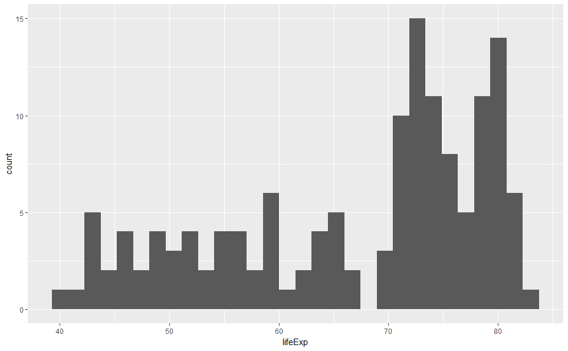

```r
gapminder %>%                           #DATA
  filter(year == 2007) %>%              #DATA
  ggplot(aes(x=lifeExp)) +              #AESTHETICS
  geom_histogram()                      #GEOM
```

Let’s examine the code before we unpack the graphic:

- You’ll recall from the `dplyr` functions that we’ve learned so far that **piping** is an effective way to write code that flows between functions. First, we piped the gapminder data to `filter()`, then we piped that filtered dataframe to `ggplot()`.
- Within ggplot’s functions (`ggplot()` and `geom_histogram()`) we **always use a plus sign**. Think of ggplot as a canvas where the graphic is built by the addition of elements.
- Then, we defined the aesthetics (`aes()`), or what we wanted to graph. In a histogram, you are simply visualizing the distribution of one variable, so you only need to tell ggplot which variable to visualize (within **x=**).
- Finally, we added the **geom** to the aesthetic, which tells ggplot the type of graphic that we wanted to create (`geom_histogram()`).

We’ll get more practice with ggplot’s three elements – data, aesthetics, and geoms – as we go.

## 5.2 Scatter plots

What might explain the variation in life expectancy across countries (*think variables from the Gapminder dataset*)?

**Scatter plots** show the relationship between two variables. Let’s create a viz of the **relationship between GDP per capita and life expectancy in 2007**. Using the previous histogram code as our starting point, we would need to change two things:

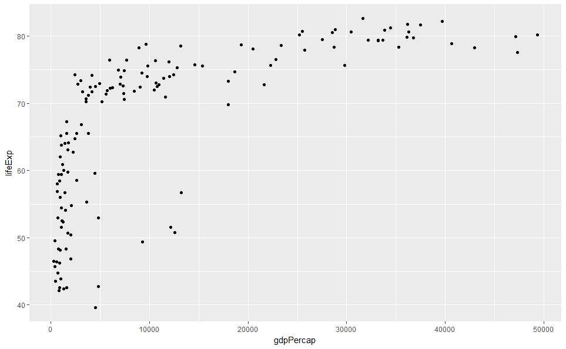

```r
gapminder %>%                           #DATA
  filter(year == 2007) %>%              #DATA
  ggplot(aes(x=gdpPercap,               #AESTHETICS
                 y=lifeExp)) +          #AESTHETICS
  geom_point()                          #GEOM
```

The graphic shows some interesting behavior:

- Many countries are clustered below $10,000 per capita, but the range of average life expectancy is quite dramatic.
- There is a saturating behavior in the data, meaning that at a certain average life expectancy (about 75 and up), income does not seem to have a strong relationship with life expectancy outcomes.
- There appears to be a strong logarithmic relationship between these variables, meaning that the x-axis has a scale that increases in orders of magnitude (1,000 - 10,000 - 100,000).

The above graphic is very interesting. However, the gapminder dataset has additional information that could be put to use to extract more value from this viz. Let’s see what this looks like when you color each point by the continent. To do this, add `color=continent` to the aesthetic.

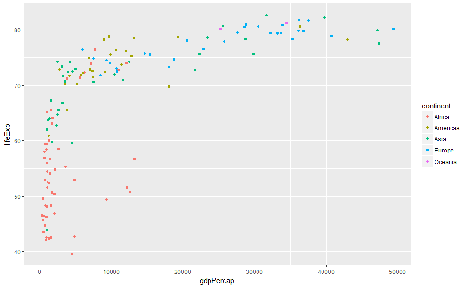

```r
gapminder %>%                         #DATA
  filter(year == 2007) %>%            #DATA
  ggplot(aes(x=gdpPercap,             #AESTHETIC
             y=lifeExp,               #AESTHETIC
             color=continent)) +      #AESTHETIC
  geom_point()                        #GEOM
```

This illustrates that many of the poorest performing countries are located in Africa.

**Exercises**:

- Set `color="blue"` in the previous code. What do you see? Why do you think that is happening?

```r
gapminder %>%                         #DATA
  filter(year == 2007) %>%            #DATA
  ggplot(aes(x=gdpPercap,             #AESTHETIC
             y=lifeExp,               #AESTHETIC
             color="blue")) +         #AESTHETIC
  geom_point()                        #GEOM
```

There are dozens of ways that you can customize `ggplot2` visualizations. With enough practice, you can have total control of the visualizations that you create. Let’s start with two very common and useful customizations:

1. Putting the x-axis on a logarithmic scale, and
2. Changing the axis labels.

To transform the x-axis to a logarithmic scale, simply add `scale_x_log10()` to the previous visualization’s code. This will compress the x-axis and show a more linear relationship than the previous graphic.

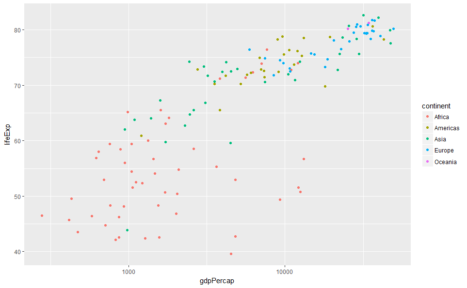

```r
gapminder %>%                             #DATA
  filter(year == 2007) %>%                #DATA
  ggplot(aes(x=gdpPercap,                 #AESTHETIC
                 y=lifeExp,               #AESTHETIC
                 color=continent)) +      #AESTHETIC
  geom_point() +                          #GEOM
  scale_x_log10()                         #CUSTOMIZING ELEMENT
```

The `labs()` command in ggplot allows users to take control of the axis labels.

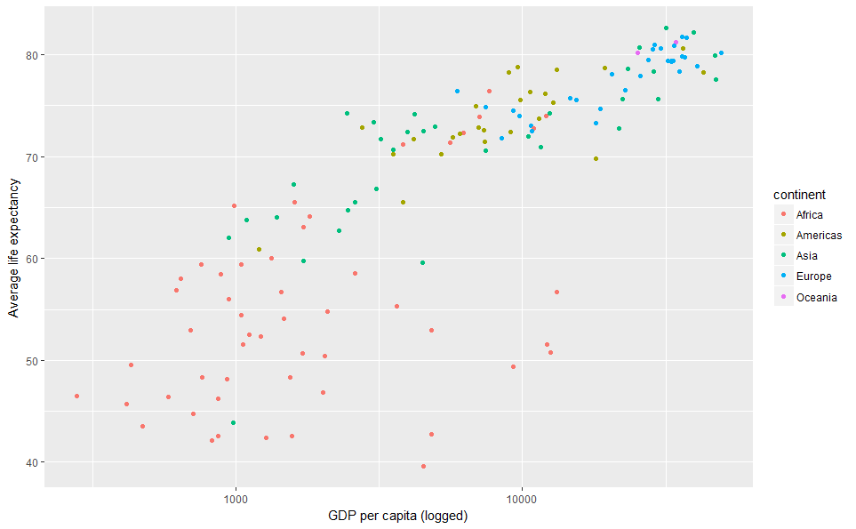

```r
gapminder %>%                             #DATA
  filter(year == 2007) %>%                #DATA
  ggplot(aes(x=gdpPercap,                 #AESTHETIC
             y=lifeExp,                   #AESTHETIC
             color=continent)) +          #AESTHETIC
  geom_point() +                          #GEOM
  scale_x_log10() +                       #CUSTOMIZING ELEMENT
  labs(x='GDP per capita (logged)',       #CUSTOMIZING ELEMENT
       y='Average life expectancy')       #CUSTOMIZING ELEMENT
```

**Exercise**:

- Create another scatterplot with another variable combination from the gapminder dataset.

## 5.3 Line plots

**Line plots** are typically used to visualize the behavior of a variable over some component of time. Let’s go back to the `gapminder_by_year_continent` dataframe that we created earlier. This is a dataframe with summary stats by continent and year. We’ll use this data to create a **line graph** showing the average life expectancy by continent over time.

**Exercises**:

- We have the **data** element already (`gapminder_by_year_continent`). What are the other two ggplot elements that we need to create a graphic?
- What would be our `x=` and `y=` arguments in the aesthetic?

```r
gapminder_by_year_continent %>%
  ggplot(aes(x=year,
             y=meanlifeExp,
             group=continent,
             color=continent)) +
  geom_line() +
  ggtitle('Life expectancy by continent over time',
          subtitle = 'Gapminder dataset') +
  labs(x='Year',
       y='Average life expectancy')
```

[output not shown]

**Exercises**:

- Plot another one of the summarised variables from the `gapminder_by_year_continent` dataframe over time.
- Using the `gapminder` dataframe, `filter()` the data on a country of your choice, and visualize a line plot over time (any variable you’d like).

```r
ex_country <- c('Zambia', 'China', 'Argentina', 'Bulgaria')

gapminder %>%
  filter(country %in% ex_country) %>%
  ggplot(aes(x=year,
             y=lifeExp,
             color=country)) +
  ggtitle('Average life expectancy at birth, select countries',
          subtitle = '1957-2007') +
  labs(x='Year',
       y='Life expectancy at birth (years)',
       caption='Gapminder dataset',
       color='') +
  geom_line() +
  theme(legend.position = 'top')
```

## 5.4 Extended use of ggplot2

There are many, many ways that you can customize or expand your visualization repertoire by understanding the three basic elements of ggplot graphics. Here is a look at two other extensions (*you can just follow along*):

- The `ggthemes` package allows for replicating the visualization themes of some major publications, including The Economist, The Wall Street Journal, and FiveThirtyEight.

```r
#install.packages("ggthemes")
library(ggthemes)
```

- You can also plot multiple geoms on the same graphic, which can be very useful in highlighting a story from your data.

What if you wanted to show a story of the improvement of life expectancy over time? You might want to fit a linear regression model to your scatter plot. The code below demonstrates how this might be done, using the visualization theme from The Economist.

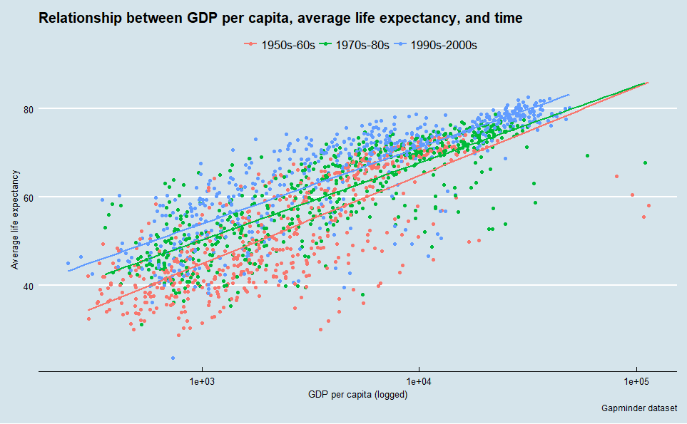

```r
gapminder %>%
  mutate(generation=ifelse(year < 1970, '1950s-60s',
                    ifelse(year >= 1970 & year < 1990, '1970s-80s', '1990s-2000s'))) %>%
  ggplot(aes(x=gdpPercap,
                 y=lifeExp,
                 color=generation)) +
  geom_point() +
  scale_x_log10() +
  geom_smooth(method = "lm", se=FALSE) +
  ggtitle('Relationship between GDP per capita, average life expectancy, and time') +
  labs(x='GDP per capita (logged)',
       y='Average life expectancy',
       color='',
       caption='Gapminder dataset') +
  theme_economist()
```

# 6 Re-cap and resources

If you’ve stayed with us this long, you’ve learned quite a few data management, manipulation, and visualization skills. The `dplyr` package has a collection of simple, yet powerful management and analysis tools. In this session, you practiced the following:

| dplyr function | Purpose |
| --- | --- |
| `dplyr::distinct()` | Returns the unique values of a variable |
| `dplyr::filter()` | Returns the observations, or rows, based on logic that you determine |
| `dplyr::arrange()` | Changes the ordering of the rows |
| `dplyr::mutate()` | Adds new variables that are functions of existing variables |
| `dplyr::summarise()` | Reduces multiple values down to a single summary |
| `dplyr::group_by()` | Groups observations by categorical variables for summary analysis |

You’ve also learned how to use `ggplot2` to visualize your data, by specifying the main elements of ggplot graphics:

| ggplot element | Purpose |
| --- | --- |
| **Data** | The dataset that you want to visualize |
| **Aesthetics**, or aesthetic mappings | The variables from the dataset that you want to visualize (and how you want to visualize them) |
| **Geoms** | The type of visualization that you want to create (scatter, bar plot, line plot, histogram, etc.) |

Finally, you’ve learned three of the most common types of visualizations – histograms, scatterplots and line plots – with `geom_histogram()`, `geom_point()`, and `geom_line()`, respectively. You’ve learned how to make small customizations to your graphics to improve the effectiveness and the amount of information contained in your visualizations, such as adding axis labels and a title, coloring your plot by another variable, and changing the scale of an axis. There are endless options/customizations within `ggplot2`, and it’s an incremental process to reach mastery. (Hopefully, a future Pardee Methods Workshop will focus exclusively on visualizing data in R!)

There are many other `dplyr` functions and `ggplot2` customizations that we couldn’t cover, such as:

- `dplyr::select()` returns the variables, or columns, that you wish to work with.
- `dplyr::rename()` allows you to change a variable name.
- `dplyr::left_join()` and `dplyr::inner_join()` are the most common functions to join two related dataframes.
- And there are dozens of other ggplot geoms and themes to take complete control over your graphics.

There are TONS of great resources for learning R. You might check out:

- Package vignettes are a great way to learn about a package or a particular function. Just type in “?InsertPackageName” or “?InsertFunctionName” (quotations excluded) to find information from R Studio’s help panel. (**FREE**)
- R-bloggers - “How to Learn R”[^5] (**FREE**)
- The John’s Hopkins Data Science Coursera[^6] (**FREE** option available)
- Swirl is an interactive course run through an R package[^7] (**FREE**)
- R Studio hosts cheat sheets for some of the most common issues, packages, and functions – including `dplyr` and `ggplot2`[^8] (**FREE**)
- There are many ggplot galleries available online that might inspire you to learn new visualization types[^9] (**FREE**)

Some parting thoughts, borrowed from a data science blog:

> 1. **Type everything**. I know you can just copy and paste from the tutorial, but do yourself a favor and type it out. You will start learning the subtleties of the syntax and get used to typing in new ways.
> 2. **Break everything and make mistakes**. When you run code that gives you the results you want, don’t stop there. Change the wording, change the symbols, try different combinations. You reinforce what is correct by understanding what is wrong and of course how to fix mistakes. Learning to fix mistakes is the fastest most effective way of learning programming (actually this is true when learning anything).
> 3. **Teach others**. One way to make sure you understand a concept is to explain it to someone else. http://cierareports.org/blog/2013/10/18/rCourse2013/

# 7 Analysis of U.S. Supreme Court data

[figure not shown]

The U.S. Supreme Court

I am providing a dataset on all U.S. Supreme Court decisions since 1946, which are organized by case and justice vote. These data come from The Supreme Court Database at the Washington University in St. Louis Law School.[^10] I’d like for you to put together the skills that you’ve learned in this session to do some exploratory analysis of the data.

First, let’s look at the data together. Read in the data with the `read.csv()` function, and save it to an object called “sup_court”. Then, use the `glimpse()` function to peek at the sup_court object.

```r
sup_court <- read.csv(url("https://github.com/mrafa3/korbel-skills-workshops/raw/master/supreme_court_1946_2018.csv"))
```

```r
glimpse(sup_court)
```

```
Observations: 78,857
Variables: 10
$ caseId        <fct> 1946-001, 1946-001, 1946-001, 1946-001, 1946-001, 1946-001, 1946-001, 1946-001, 1946-...
$ caseName      <fct> HALLIBURTON OIL WELL CEMENTING CO. v. WALKER et al., DOING BUSINESS AS DEPTHOGRAPH CO...
$ term          <int> 1946, 1946, 1946, 1946, 1946, 1946, 1946, 1946, 1946, 1946, 1946, 1946, 1946, 1946, 1...
$ chief         <fct> Vinson, Vinson, Vinson, Vinson, Vinson, Vinson, Vinson, Vinson, Vinson, Vinson, Vinso...
$ majVotes      <int> 8, 8, 8, 8, 8, 8, 8, 8, 8, 6, 6, 6, 6, 6, 6, 6, 6, 6, 5, 5, 5, 5, 5, 5, 5, 5, 5, 5, 5...
$ minVotes      <int> 1, 1, 1, 1, 1, 1, 1, 1, 1, 3, 3, 3, 3, 3, 3, 3, 3, 3, 4, 4, 4, 4, 4, 4, 4, 4, 4, 3, 3...
$ justiceName   <fct> HHBurton, RHJackson, WODouglas, FFrankfurter, SFReed, HLBlack, WBRutledge, FMurphy, F...
$ issueAreaName <fct> Economic Activity, Economic Activity, Economic Activity, Economic Activity, Economic ...
$ directionName <fct> conservative, liberal, liberal, liberal, liberal, liberal, liberal, liberal, liberal,...
$ majorityName  <fct> dissent, majority, majority, majority, majority, majority, majority, majority, majori...
```

Explore the dataset on your own, and see what you can find! Try to ask a question of the dataset and come up with an answer. In case you want some examples to guide you, you might ask (the “Code” box is there if you are stuck, but try your best to do this on your own.)…

- Which Chief Justice has presided over the most cases since 1946? Which has heard the fewest?

```r
sup_court %>%
  group_by(chief) %>%
  summarise(count_cases = n()) %>%
  arrange(desc(count_cases))
```

- How many decisions has Justice Gorsuch made in his short tenure on the bench? How often has he cast a dissenting opinion? How often has he made decisions that would be considered conservative? What types of cases has he heard most often to this point? (hint: Gorsuch can be found using the justiceName variable with **NMGorsuch**.)

```r
sup_court %>%
  filter(justiceName == 'NMGorsuch') %>%
  group_by(justiceName) %>%
  summarise(count_cases = n())
```

```r
sup_court %>%
  filter(justiceName == 'NMGorsuch') %>%
  group_by(justiceName, majorityName) %>%
  summarise(count_cases = n())
```

```r
sup_court %>%
  filter(justiceName == 'NMGorsuch') %>%
  group_by(justiceName, directionName) %>%
  summarise(count_cases = n())
```

```r
sup_court %>%
  filter(justiceName == 'NMGorsuch') %>%
  group_by(justiceName, issueAreaName) %>%
  summarise(count_cases = n()) %>%
  mutate(perc_cases = round(count_cases / sum(count_cases) * 100, 1)) %>%
  arrange(desc(perc_cases))
```

- Justice Kennedy has a reputation as being the swing voter on the Supreme Court. How might you test this conventional wisdom with this dataset? (hint: you might consider using the **majVotes** and **minVotes** variables for this question)

```r
sup_court %>%
  filter(majVotes == 5,
         minVotes == 4) %>%
  group_by(justiceName, majorityName) %>%
  summarise(count_cases = n()) %>%
  mutate(perc_cases = round(count_cases / sum(count_cases) * 100, 1)) %>%
  arrange(desc(perc_cases))
```

- Which justice has heard the most Supreme Court Cases since 1946? (hint: the justice is the primary unit of analysis)

```r
sup_court %>%
  group_by(justiceName) %>%
  summarise(count_cases = n()) %>%
  arrange(desc(count_cases))
```

- What are the trends in the types of case heard by term? What is the trend in civil rights cases – compared with other issue areas – over time? (hint: **BY term and issue area**)

```r
(sup_court_term_issue <- sup_court %>%
  group_by(term, issueAreaName) %>%
  summarise(count_cases = n()) %>%
  arrange(term, desc(count_cases)))
```

```r
sup_court_term_issue %>%
  filter(!is.na(issueAreaName)) %>%
  ggplot(.) +
  geom_line(aes(x=term,
                y=count_cases,
                color=issueAreaName))
```

```r
sup_court_term_issue %>%
  filter(!is.na(issueAreaName)) %>%
  mutate(CivilRights = ifelse(issueAreaName=='Civil Rights', 'Civil Rights', 'Other')) %>%
  ggplot(.) +
  geom_line(aes(x=term,
                y=count_cases,
                group=issueAreaName,
                color=CivilRights)) +
  scale_color_manual(values = c('Civil Rights' = 'darkgreen',
                                'Other' = 'lightgray'))
```

- Does the Court seem to have strong tendencies for votes based on the issue area? (*Probably many ways that you could think about answering this one.*)

```r
#Restricting to cases since 1980
baseline_vote <- sup_court %>%
  filter(term > 1980) %>%
  mutate(liberal_vote = ifelse(directionName == 'liberal', 1,
                        ifelse(directionName == 'conservative', 0, NA))) %>%
  group_by(issueAreaName) %>%
  summarise(baseline_issue_vote = mean(liberal_vote, na.rm = TRUE)) %>%
  filter(!is.na(baseline_issue_vote)) %>%
  arrange(-baseline_issue_vote) %>%
  ungroup()
```

- Justice Scalia was known as a staunch conservative presence on the bench. Were there some issues that he leaned more centrist? (hint: `group_by()` and `summarise()` would come in handy here, yet again)

```r
sup_court %>%
  filter(justiceName == 'AScalia') %>%
  group_by(justiceName, issueAreaName, directionName) %>%
  summarise(count_cases = n()) %>%
  mutate(perc_cases = round(count_cases / sum(count_cases) *100, 1)) %>%
  filter(directionName == 'liberal') %>%
  arrange(-perc_cases)
```

- To truly answer a question like the previous one, you would want to take into account the directionality of all voting justices by issue area. For instance, if you explored the previous question, you found that Scalia voted “liberal” on almost 70% of Federal Taxation cases. However, if the Court has a tendency to vote liberal on this issue, then Scalia might not be as “liberal” on this issue as it might seem. This question is a bit more complicated, but does Scalia *lean liberal* based on the Court’s tendencies in Federal Taxation Cases? (*This question still uses `dplyr` – and if you’d like, `ggplot2` – but with a few bells and whistles.*)

```r
sup_court_fedtax <- sup_court %>%
  filter(term > 1980, issueAreaName == 'Federal Taxation') %>%
  group_by(justiceName, issueAreaName, directionName) %>%
  summarise(count_cases = n()) %>%
  mutate(perc_cases = count_cases / sum(count_cases)) %>%
  filter(directionName == 'liberal') %>%
  ungroup() %>%
  left_join(x=.,
            y=baseline_vote,
            by='issueAreaName')
```

```r
library(scales)                 #for changing axis label to include '%'
```

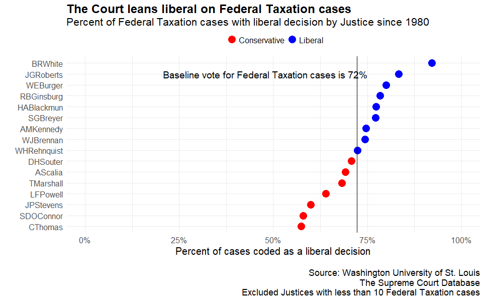

```r
sup_court_fedtax %>%
  filter(count_cases >=10) %>%
  mutate(fedtax_lean = ifelse(perc_cases > baseline_issue_vote, 'Liberal', 'Conservative')) %>%
  ggplot(.) +
  geom_point(aes(x=perc_cases,
                 y=reorder(justiceName, perc_cases),
                 color=fedtax_lean), size=5) +
  geom_vline(xintercept = sup_court_fedtax$baseline_issue_vote) +
  annotate(geom='text', x=.48, y='JGRoberts',
           label=paste('Baseline vote for Federal Taxation cases is ',
                       round(sup_court_fedtax$baseline_issue_vote[1] * 100), '%', sep = ''),
           size=5) +
  scale_x_continuous(labels = percent,
                     limits = c(0, 1)) +
  ggtitle('The Court leans liberal on Federal Taxation cases',
          subtitle = 'Percent of Federal Taxation cases with liberal decision by Justice since 1980') +
  labs(x='Percent of cases coded as a liberal decision\n',
       y='',
       color='',
       caption='Source: Washington University of St. Louis\nThe Supreme Court Database\nExcluded Justices with less than 10 Federal Taxation cases') +
  theme_minimal() +
  scale_color_manual(values = c('Liberal' = 'blue',
                                'Conservative' = 'red')) +
  theme(legend.position = 'top',
        text = element_text(size=15),
        plot.title = element_text(size=18, face='bold'),
        plot.subtitle = element_text(size=16),
        strip.text = element_text(size=15, face='bold'))
```

[^1]: https://www.tidyverse.org/packages/
[^2]: https://cran.r-project.org/web/packages/dplyr/vignettes/dplyr.html
[^3]: For an extremely in-depth article on pipe operators, including where they came from and why they are so useful, see here: https://www.datacamp.com/community/tutorials/pipe-r-tutorial
[^4]: This is a useful reference for learning about all of the geom options in ggplot. This might look overwhelming, but it is something that you pick up more as you move into more exotic visualization types. (http://ggplot2.tidyverse.org/reference/#section-layer-geoms)
[^5]: https://www.r-bloggers.com/how-to-learn-r-2/
[^6]: https://www.coursera.org/specializations/jhu-data-science
[^7]: http://www.swirlstats.com/
[^8]: https://www.rstudio.com/resources/cheatsheets/
[^9]: http://r-statistics.co/Top50-Ggplot2-Visualizations-MasterList-R-Code.html
[^10]: http://scdb.wustl.edu/data.php